# Reproducible RNA-seq Analysis of Idiopathic Pulmonary Fibrosis

GSE213001 | Donor-aware IPF vs NDC transcriptomic analysis

Author

Joan Carreras Díaz

Published

October 23, 2026

# 1 Study objective and dataset

This project provides a reproducible bulk RNA-seq analysis of idiopathic pulmonary fibrosis (IPF) using public data from GEO accession **GSE213001**.

The primary scientific question is:

> Which transcriptional programs distinguish idiopathic pulmonary fibrosis from non-diseased lung tissue while accounting for anatomical lung region and repeated samples from the same donor?

The primary comparison is **IPF versus non-diseased controls (NDC)**.

The complete source dataset contains 139 samples from 46 donors across IPF, NDC, ILD, and CLAD disease groups. The primary IPF-vs-NDC analysis was restricted according to the prespecified study design.

Because multiple tissue samples may originate from the same donor, tissue samples were not treated as independent biological replicates.

The project follows a staged analytical structure:

- W1-W4: data ingestion, metadata validation, quality control, filtering, normalization, and ordination;
- W5: frozen primary donor-aware differential-expression analysis;
- W6: frozen controlled pathway enrichment and biological interpretation;
- W7: frozen age and gender sensitivity analyses and robustness synthesis;
- W8: portfolio visualization, final reporting, and reproducibility communication.

W8 does not constitute a new inferential analysis stage.

# 2 Cohort and analytical design

The planned IPF-vs-NDC cohort initially contained 103 samples from 34 donors.

Two samples had missing lung-region information. Because lung region was a prespecified adjustment variable, those samples were excluded from the primary model before differential-expression testing.

The frozen primary cohort therefore contains:

| Group | Samples |
| --- | --- |
| IPF | 61 |
| NDC | 40 |
| **Total** | **101** |

These 101 samples represent **34 donors**.

The anatomical distribution is:

| Group | Apex | Base | Total |
| --- | --- | --- | --- |
| IPF | 30 | 31 | 61 |
| NDC | 22 | 18 | 40 |
| **Total** | **52** | **49** | **101** |

The frozen primary statistical model is a donor-aware limma-voom analysis with the fixed-effects structure:

`~ diseasegroup + lunglocation`

Repeated observations from the same donor are handled using `duplicateCorrelation()` rather than by treating samples as independent replicates.

The final estimated consensus within-donor correlation was approximately **0.316**.

The principal inferential effect is the disease contrast **IPF versus NDC**, adjusted for anatomical lung region.

Age and gender were not automatically added to the primary model. They were evaluated later as prespecified W7 sensitivity analyses so that their impact on the frozen W5 result could be assessed without redefining the primary analysis.

# 3 Quality-control overview

Quality control was completed before formal differential-expression testing.

The workflow included:

- explicit alignment of sample metadata to count-matrix columns;
- validation of donor and disease-group information;
- assessment of repeated samples within donors;
- library-level count QC;
- review of technical variables;
- low-count filtering;
- TMM normalization;
- exploratory PCA and edgeR MDS;
- inspection of sample relationships and possible technical structure;
- preparation of the donor-aware primary design.

No sample was excluded solely because of PCA or MDS position or because its removal would improve biological group separation.

The raw statistical universe contained 15,065 genes before low-count filtering. The frozen analysis universe contains **15,012 genes**.

No filtering, normalization, sample exclusion, or QC threshold is recalculated during this final report.

# 4 Frozen W5 differential-expression results

The W5 analysis is the principal inferential result of the project.

Across the frozen 15,012-gene universe:

| W5 metric | Result |
| --- | --- |
| Genes tested | 15,012 |
| Genes with raw P < 0.05 | 8,679 |
| Genes with FDR < 0.05 | 7,898 |
| FDR-significant, higher in IPF | 3,964 |
| FDR-significant, lower in IPF | 3,934 |
| Genes with absolute log2FC >= 1 | 1,884 |
| FDR < 0.05 and absolute log2FC >= 1 | 1,861 |
| Minimum raw P value | 1.10 × 10^-28 |
| Minimum BH-adjusted P value | 1.65 × 10^-24 |

The prespecified inferential significance criterion is **FDR < 0.05**.

No additional effect-size significance threshold is imposed on the primary classification.

The balance between genes higher and lower in IPF indicates extensive transcriptomic differences in both directions rather than a globally unidirectional shift.

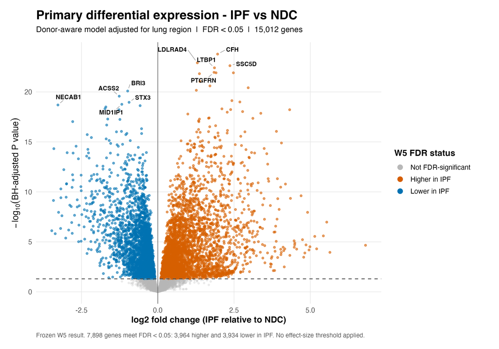

Frozen W5 primary donor-aware differential-expression result. Orange points represent FDR-significant genes higher in IPF, blue points represent FDR-significant genes lower in IPF, and grey points do not satisfy FDR < 0.05. The ten displayed labels are deterministic presentation labels selected from the frozen result and do not redefine inferential ranking.

The volcano visualization is a presentation layer generated directly from the frozen W5 gene-level result. Differential expression, P values, adjusted P values, log fold changes, and gene classifications were not recomputed during W8.

# 5 Frozen W6 biological interpretation

W6 translated the frozen differential-expression result into a controlled pathway-level biological interpretation.

Three frozen evidence streams were evaluated:

1. GO Biological Process over-representation analysis;
2. Reactome over-representation analysis;
3. GO Biological Process ranked enrichment.

Interpretation was organized into eight controlled biological themes rather than allowing post hoc pathway selection to redefine the biological narrative.

## 5.1 Higher in IPF

Strong convergent pathway-level support higher in IPF included:

- **extracellular-matrix / collagen / fibrotic remodeling**, with support from all three evidence streams;
- **tissue-development / structural remodeling**, with support from all three evidence streams;
- **broad signalling or mixed processes requiring pathway-specific caution**, with support from all three evidence streams;
- **cilium / axoneme / microtubule-associated motility**, with support from two evidence streams.

The extracellular-matrix and structural-remodeling findings are consistent with a broad remodeling-associated transcriptomic pattern in IPF tissue.

The broad-signalling category is intentionally interpreted cautiously because it aggregates heterogeneous pathway processes.

## 5.2 Lower in IPF

Convergent pathway-level support lower in IPF included:

- **mucosal / antimicrobial / innate immune response**;
- **leukocyte / neutrophil-associated processes**;
- **surfactant / lipid / sterol metabolism**;
- **broad signalling or mixed processes requiring pathway-specific caution**.

The **mitochondrial respiration / oxidative phosphorylation / ATP production** theme had support from a single frozen evidence stream and is therefore treated as contextual rather than convergent evidence.

Some theme-direction combinations had no controlled pathway-level support. This is **not** interpreted as evidence that the underlying biology is absent.

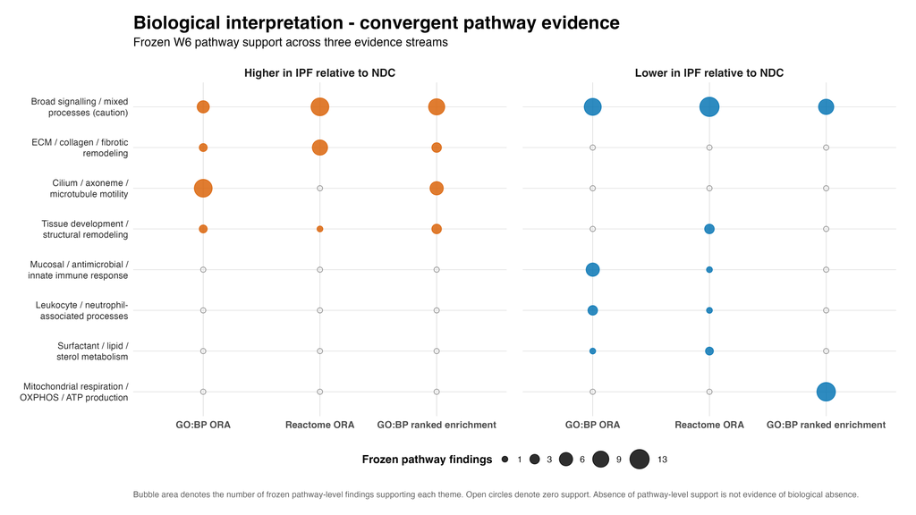

Frozen W6 biological interpretation summarized across GO:BP ORA, Reactome ORA, and GO:BP ranked enrichment. Bubble area represents the number of frozen pathway-level findings supporting each controlled theme. Open circles denote zero pathway-level support and must not be interpreted as biological absence.

These pathway-level findings are associative and descriptive. They do not establish causal mechanisms.

No pathway was promoted, removed, re-ranked, or recalculated during W8.

# 6 Frozen W7 sensitivity and robustness

W7 evaluated whether the frozen W5 IPF-vs-NDC result remained stable after two prespecified covariate adjustments:

- continuous age;
- gender.

These analyses were sensitivity analyses, not replacements for the primary W5 model.

## 6.1 Continuous-age adjustment

After continuous-age adjustment:

- 5,277 genes satisfied FDR < 0.05;
- 5,015 of the original W5 FDR-significant genes remained significant;
- W5 FDR retention was **0.6350**;
- Pearson logFC agreement with W5 was **0.9656**;
- Spearman logFC agreement was **0.9509**;
- genome-wide directional concordance was **0.9127**;
- median absolute change in logFC was **0.0710**;
- the 95th percentile absolute change in logFC was **0.4072**;
- shared-FDR directional concordance was **1.0000**.

## 6.2 Gender adjustment

After gender adjustment:

- 7,745 genes satisfied FDR < 0.05;
- 7,596 of the original W5 FDR-significant genes remained significant;
- W5 FDR retention was **0.9618**;
- Pearson logFC agreement with W5 was **0.9946**;
- Spearman logFC agreement was **0.9965**;
- genome-wide directional concordance was **0.9885**;
- median absolute change in logFC was **0.0086**;
- the 95th percentile absolute change in logFC was **0.1110**;
- shared-FDR directional concordance was **1.0000**.

## 6.3 Cross-sensitivity interpretation

The two sensitivity analyses distinguish two different aspects of robustness.

The **genome-wide effect pattern** remained strongly concordant with W5 under both adjustments.

The **FDR-defined discovery set** was more sensitive to continuous-age adjustment than to gender adjustment.

Importantly, genes significant in both the primary and sensitivity analyses retained complete directional concordance in both cases.

Therefore, the reduced FDR retention after age adjustment should not be interpreted as reversal of the underlying transcriptomic pattern.

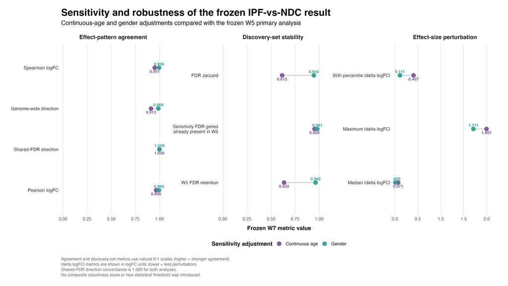

Frozen W7 robustness summary. Continuous-age and gender sensitivity analyses are compared with the W5 primary result across effect-pattern agreement, discovery-set stability, and effect-size perturbation.

The W7 analyses support robustness of the principal W5 effect pattern to the evaluated adjustments while showing that threshold-defined discovery-set membership is more sensitive to continuous age.

These analyses do not establish that age or gender has no biological or statistical influence.

# 7 Limitations

Several limitations define the appropriate interpretation of this project.

First, GSE213001 is a public observational dataset. The analysis identifies associations between disease status and transcriptomic measurements; it does not establish causality.

Second, the data are bulk tissue RNA-seq. Observed transcriptional differences may therefore reflect both within-cell expression changes and differences in cellular composition. Cell-type-specific mechanisms cannot be resolved directly from this analysis.

Third, repeated tissue samples are available for many donors. Donor-aware correlation modelling addresses the non-independence of repeated observations, but it does not remove all biological heterogeneity among individuals or lung regions.

Fourth, the primary model intentionally prioritizes a prespecified and interpretable disease-plus-region structure. Other available clinical or technical variables may also contribute to transcriptomic variation.

Fifth, membership in an FDR-defined gene set depends on statistical uncertainty and the chosen multiple-testing threshold. The W7 age sensitivity analysis illustrates why changes in discovery-set size must be interpreted separately from changes in the underlying genome-wide effect pattern.

Sixth, pathway enrichment depends on existing gene-set definitions and pathway annotation. Lack of pathway-level support is not equivalent to evidence of biological absence.

Finally, conclusions are specific to this dataset, analytical design, and frozen comparison. Generalization beyond GSE213001 requires independent validation.

# 8 Reproducibility information

The project was developed as a version-controlled analysis using:

- R;
- Bioconductor;
- `renv`;
- `targets`;
- Quarto;
- Git;
- GitHub.

Raw/source data are preserved separately from processed analytical outputs.

Analytical decisions are documented prospectively in `docs/DECISIONS.md`.

The cohort and experimental design are documented in `docs/STUDY_DESIGN.md`.

The early workflow is represented in `_targets.R`, while later analytical stages were frozen through explicit version-controlled scripts, outputs, QC records, commits, and analytical checkpoints.

The existence of `_targets.R` should therefore not be interpreted as meaning that the W5-W8 results are regenerated automatically by `tar_make()`.

This final Quarto report is deliberately a **reporting layer**. It embeds previously frozen outputs and does not execute statistical modelling, normalization, enrichment, or sensitivity analysis.

The analytical provenance is:

| Stage | Frozen role |
| --- | --- |
| W1-W4 | Data preparation, QC, filtering, normalization, ordination |
| W5 | Primary donor-aware differential expression |
| W6 | Controlled enrichment and biological interpretation |
| W7 | Age and gender sensitivity analyses and robustness synthesis |
| W8 | Portfolio visualization and final reporting |

The final portfolio figures are stored under `figures/final/`, while their associated W8 QC records are stored under `metadata/`.

# 9 Final conclusions

This project identifies a broad and reproducible transcriptomic distinction between IPF and non-diseased lung tissue in GSE213001 using a donor-aware analysis that explicitly accounts for repeated sampling and anatomical lung region.

The frozen primary W5 analysis tested **15,012 genes** and identified **7,898 genes at FDR < 0.05**, divided almost evenly between genes higher and lower in IPF.

Controlled W6 pathway interpretation highlighted convergent evidence for extracellular-matrix and structural-remodeling programs higher in IPF, while several immune, surfactant/lipid, and related programs showed pathway-level support lower in IPF. Broader signalling categories required pathway-specific caution, and lack of pathway support was not interpreted as biological absence.

The prespecified W7 analyses showed that the principal genome-wide effect pattern remained strongly concordant after both continuous-age and gender adjustment. Gender adjustment produced only minor perturbation, whereas age adjustment had a larger impact on membership of the FDR-significant discovery set. In both sensitivity analyses, genes significant in both analyses retained complete directional concordance.

Together, these results support the stability of the principal IPF-vs-NDC transcriptomic pattern while also demonstrating the importance of separating effect-pattern robustness from threshold-dependent discovery-set stability.

The frozen W5 primary analysis remains the principal inferential reference. W6 provides its controlled biological interpretation, W7 provides its prespecified robustness assessment, and W8 communicates the completed analysis without altering its scientific conclusions.